# Validation of determining tissue adjacency based machine-learning derived annotations, quantification of tumor adjacency to tissue classes and lobular NGFR intensity

Annika Viljamaa

2025-05-20

# 1 Load required packages

```r
# re-framing the data
library(dplyr)

# plots
library(ggplot2)
library(ggalluvial)
library(RColorBrewer)
library(circlize)
library(ggforce)
```

# 2 Adjacent tissues with tumor cell detections

## 2.1 Import the data

Data include measured distances from tumor cell centroids to the closest tissue annotations within stromal and lobular ROIs, and distance to invasion front for lobular ROIs.

```r
setwd("/Users/sara.soderqvist/Library/CloudStorage/OneDrive-KarolinskaInstitutet/Writing_/Adaptive PDAC paper/Code/ML tumor interactions and cell-based NGFR intensity") #adjust working directory

# distance frame with invasion front
dist.frame.original <- read.table('./data/tumor_tissue_interactions_ngfr_intensity.tsv', sep = '\t', header = T)
dim(dist.frame.original) #23,390 observations in total
```

[1] 23390 124

```r
knitr::kable(head(dist.frame.original))
```

| Image | Object.ID | Object.type | Name | Classification | Parent | ROI | Centroid.X.µm | Centroid.Y.µm | Nucleus..Area | Nucleus..Perimeter | Nucleus..Circularity | Nucleus..Max.caliper | Nucleus..Min.caliper | Nucleus..Eccentricity | Nucleus..Hematoxylin.OD.mean | Nucleus..Hematoxylin.OD.sum | Nucleus..Hematoxylin.OD.std.dev | Nucleus..Hematoxylin.OD.max | Nucleus..Hematoxylin.OD.min | Nucleus..Hematoxylin.OD.range | Nucleus..DAB.OD.mean | Nucleus..DAB.OD.sum | Nucleus..DAB.OD.std.dev | Nucleus..DAB.OD.max | Nucleus..DAB.OD.min | Nucleus..DAB.OD.range | Nucleus..AP.OD.mean | Nucleus..AP.OD.sum | Nucleus..AP.OD.std.dev | … |
| --- | --- | --- | --- | --- | --- | --- | --- | --- | --- | --- | --- | --- | --- | --- | --- | --- | --- | --- | --- | --- | --- | --- | --- | --- | --- | --- | --- | --- | --- | --- |
| PKR-24-cd146_ngfr distance to preserved lobules_wIntensity_updated_invf.ndpi | fb408f55-7a5b-41d2-94c3-3598834ec674 | Cell | NA | stroma 1 | Annotation (tumor) | Polygon | 33042.1 | 11183.7 | 45.2002 | 25.0045 | 0.9085 | 8.8529 | 6.8641 | 0.6082 | 0.3432 | 73.7948 | 0.1473 | 0.6971 | -0.0620 | 0.7590 | 0.1489 | 32.0132 | 0.0900 | 0.4623 | -0.0194 | 0.4817 | -0.0100 | -2.1597 | 0.1255 | … |
| PKR-24-cd146_ngfr distance to preserved lobules_wIntensity_updated_invf.ndpi | e888bb43-5b55-4d3b-9ee1-67da9c18bb69 | Cell | NA | stroma 1 | Annotation (tumor) | Polygon | 33059.2 | 11186.2 | 64.9354 | 31.1473 | 0.8411 | 11.4657 | 7.6195 | 0.7337 | 0.3632 | 111.1503 | 0.1524 | 0.7593 | 0.0123 | 0.7470 | 0.0451 | 13.7992 | 0.0754 | 0.2324 | -0.1466 | 0.3790 | 0.0463 | 14.1718 | 0.1504 | … |
| PKR-24-cd146_ngfr distance to preserved lobules_wIntensity_updated_invf.ndpi | 8191bda8-1ecf-4f20-99b3-f58cbaba0498 | Cell | NA | stroma 1 | Annotation (tumor) | Polygon | 33047.9 | 11198.1 | 37.9851 | 26.9797 | 0.6558 | 10.4255 | 5.4412 | 0.8859 | 0.3720 | 69.9350 | 0.1848 | 0.7727 | -0.0279 | 0.8005 | 0.0782 | 14.7021 | 0.0934 | 0.3769 | -0.1883 | 0.5652 | -0.0151 | -2.8449 | 0.1429 | … |
| PKR-24-cd146_ngfr distance to preserved lobules_wIntensity_updated_invf.ndpi | 00c1aaed-7be5-44e9-a2e8-0b2ac8a6bcbf | Cell | NA | stroma 1 | Annotation (tumor) | Polygon | 33061.8 | 11199.9 | 28.0114 | 21.1139 | 0.7896 | 7.8055 | 5.0139 | 0.7781 | 0.2757 | 36.3867 | 0.1335 | 0.7737 | -0.0339 | 0.8077 | 0.0970 | 12.8023 | 0.0518 | 0.2378 | -0.0626 | 0.3003 | -0.0907 | -11.9756 | 0.0941 | … |
| PKR-24-cd146_ngfr distance to preserved lobules_wIntensity_updated_invf.ndpi | 1f67e61a-fe53-4df2-bfd3-850909f17ad8 | Cell | NA | stroma 1 | Annotation (tumor) | Polygon | 33080.0 | 11201.9 | 34.8020 | 22.0747 | 0.8975 | 7.8740 | 5.4357 | 0.7230 | 0.3931 | 65.2473 | 0.1229 | 0.7151 | 0.1577 | 0.5574 | 0.0470 | 7.7995 | 0.1037 | 0.2932 | -0.1765 | 0.4697 | 0.0168 | 2.7929 | 0.1417 | … |
| PKR-24-cd146_ngfr distance to preserved lobules_wIntensity_updated_invf.ndpi | 71b2e432-90c4-4c23-a9cc-f81b1f0e7139 | Cell | NA | stroma 1 | Annotation (tumor) | Polygon | 33031.2 | 11208.3 | 46.4734 | 28.3643 | 0.7259 | 10.9394 | 6.3943 | 0.8185 | 0.3758 | 83.0456 | 0.1249 | 0.7405 | 0.1086 | 0.6319 | -0.0290 | -6.4186 | 0.0939 | 0.1973 | -0.2345 | 0.4318 | 0.2143 | 47.3686 | 0.1693 | … |

## 2.2 Cleaning

Modifications of the imported data frame includes cleaning and transforming the data suitable for analysis and visualization.

```r
# remove duplicate observations
colnames(dist.frame.original) <- gsub('\\.with', '', colnames(dist.frame.original))

dist.frame.original <- dist.frame.original[, !duplicated(names(dist.frame.original))]

colnames(dist.frame.original)
```

```
##   [1] "Image"
##   [2] "Object.ID"
##   [3] "Object.type"
##   [4] "Name"
##   [5] "Classification"
##   [6] "Parent"
##   [7] "ROI"
##   [8] "Centroid.X.µm"
##   [9] "Centroid.Y.µm"
##  [10] "Nucleus..Area"
##  [11] "Nucleus..Perimeter"
##  [12] "Nucleus..Circularity"
##  [13] "Nucleus..Max.caliper"
##  [14] "Nucleus..Min.caliper"
##  [15] "Nucleus..Eccentricity"
```

[output cut: 89 more lines]

```r
dist.frame.original$Distance.to.annotation.lobe.1_InvasionFront.µm <- ifelse(is.na(dist.frame.original$Distance.to.annotation.lobe.1_InvasionFrontUpdated.µm), dist.frame.original$Distance.to.annotation.lobe.1_InvasionFront.µm, dist.frame.original$Distance.to.annotation.lobe.1_InvasionFrontUpdated.µm)

dist.frame.original$Distance.to.annotation.lobe.3_InvasionFront.µm <- ifelse(is.na(dist.frame.original$Distance.to.annotation.lobe.3_InvasionFrontUpdated.µm), dist.frame.original$Distance.to.annotation.lobe.3_InvasionFront.µm, dist.frame.original$Distance.to.annotation.lobe.3_InvasionFrontUpdated.µm)

dist.frame.original <- dist.frame.original%>%
  select(!c(Distance.to.annotation.lobe.1_InvasionFrontUpdated.µm, Distance.to.annotation.lobe.3_InvasionFrontUpdated.µm))
```

```r
# Subset the data to have only relevant information
dist_frame <- dist.frame.original %>%
  dplyr::select(Image, Classification, Object.ID, ends_with('AP..Mean'), starts_with('Distance'))%>%
  data.frame()

# Simplify column and variable names
names <- colnames(dist_frame[,5:ncol(dist_frame)])
names <- gsub("Distance.to.annotation.", "", names)
names <- gsub(".µm", "", names)

dist_frame$Image <- gsub("-CD146.*|-cd146.*","",dist_frame$Image)
unique(dist_frame$Image) # only case information left
```

[1] “PKR-24” “PKR-2” “PKR-13” “PKR-39” “PKR-51”

```r
colnames(dist_frame) <- c('PKR', 'ROI', 'Object.ID', 'AP_mean', names)

# exclude irrelevant distance measurements
dist_frame <- dist_frame %>%
  dplyr::select(PKR, ROI, Object.ID, AP_mean, Langerhans, acinar, nerve, vessel, ADM, ductal, immune, tumor, fibroblasts, ends_with('Front')) %>%
  data.frame()

# convert to long format
dist_frame <- dist_frame %>%
  tidyr::pivot_longer(cols = c(colnames(dist_frame[,5:ncol(dist_frame)])),
                      names_to = 'to_class',
                      values_to = 'distance_um')

#create a new column to have plain info on the ROI (stroma/lobe)
dist_frame <- dist_frame %>%
  tidyr::separate(col=ROI, into=c('roi', 'roi_no'), sep = ' ', remove = T)%>%
  mutate(roi_no = paste(roi, roi_no, sep="-"))%>%
  data.frame()

# add a column with combined case and ROI info
dist_frame$PKR_ROI = paste(dist_frame$PKR, dist_frame$roi_no, sep="-")

# subset to quality control
pkr51 <-  dist_frame %>%
  filter(PKR == 'PKR-51')%>%
  data.frame()

nrow(dist_frame)
```

[1] 304070

```r
dist_frame <- dist_frame%>%
  filter(!PKR_ROI %in% c('PKR-51-lobe-2', 'PKR-51-lobe-3'))%>%
  data.frame()
nrow(dist_frame) #9555 rows were excluded
```

[1] 294515

```r
# convertion & new columns look as they should
knitr::kable(head(dist_frame))
```

| PKR | roi | roi_no | Object.ID | AP_mean | to_class | distance_um | PKR_ROI |
| --- | --- | --- | --- | --- | --- | --- | --- |
| PKR-24 | stroma | stroma-1 | fb408f55-7a5b-41d2-94c3-3598834ec674 | -0.0018 | Langerhans | 1731.5742 | PKR-24-stroma-1 |
| PKR-24 | stroma | stroma-1 | fb408f55-7a5b-41d2-94c3-3598834ec674 | -0.0018 | acinar | 403.3814 | PKR-24-stroma-1 |
| PKR-24 | stroma | stroma-1 | fb408f55-7a5b-41d2-94c3-3598834ec674 | -0.0018 | nerve | 41.0591 | PKR-24-stroma-1 |
| PKR-24 | stroma | stroma-1 | fb408f55-7a5b-41d2-94c3-3598834ec674 | -0.0018 | vessel | 35.1566 | PKR-24-stroma-1 |
| PKR-24 | stroma | stroma-1 | fb408f55-7a5b-41d2-94c3-3598834ec674 | -0.0018 | ADM | 417.2464 | PKR-24-stroma-1 |
| PKR-24 | stroma | stroma-1 | fb408f55-7a5b-41d2-94c3-3598834ec674 | -0.0018 | ductal | 92.0245 | PKR-24-stroma-1 |

## 2.3 Quality control

Control that data looks as it should after modifications

```r
# All variables are included
unique(dist_frame$PKR)
```

[1] “PKR-24” “PKR-2” “PKR-13” “PKR-39” “PKR-51”

```r
unique(dist_frame$roi_no)
```

[1] “stroma-1” “lobe-3” “stroma-3” “lobe-4” “stroma-4” “lobe-2”  
[7] “stroma-2” “lobe-1” “stroma-5” “stroma-6”

```r
unique(dist_frame$to_class)
```

[1] “Langerhans” “acinar” “nerve”  
[4] “vessel” “ADM” “ductal”  
[7] “immune” “tumor” “fibroblasts”  
[10] “lobe.3_InvasionFront” “lobe.2_InvasionFront” “lobe.4_InvasionFront” [13] “lobe.1_InvasionFront”

```r
unique(dist_frame$PKR_ROI)
```

[1] “PKR-24-stroma-1” “PKR-24-lobe-3” “PKR-24-stroma-3” “PKR-24-lobe-4”  
[5] “PKR-24-stroma-4” “PKR-24-lobe-2” “PKR-24-stroma-2” “PKR-24-lobe-1”  
[9] “PKR-2-stroma-4” “PKR-2-stroma-5” “PKR-2-stroma-6” “PKR-2-stroma-1” [13] “PKR-2-stroma-3” “PKR-2-stroma-2” “PKR-2-lobe-2” “PKR-2-lobe-1”  
[17] “PKR-2-lobe-4” “PKR-2-lobe-3” “PKR-13-lobe-3” “PKR-13-stroma-4” [21] “PKR-13-stroma-5” “PKR-13-stroma-2” “PKR-13-stroma-3” “PKR-13-lobe-2”  
[25] “PKR-13-stroma-1” “PKR-13-lobe-1” “PKR-39-lobe-3” “PKR-39-stroma-5” [29] “PKR-39-lobe-2” “PKR-39-stroma-4” “PKR-39-stroma-6” “PKR-39-stroma-2” [33] “PKR-39-stroma-1” “PKR-39-stroma-3” “PKR-39-lobe-1” “PKR-51-stroma-1” [37] “PKR-51-stroma-2” “PKR-51-stroma-3” “PKR-51-stroma-5” “PKR-51-stroma-4” [41] “PKR-51-lobe-1”

```r
(nrow(dist_frame)+9555)/13 #number of rows divided by the number of cell classes & distance to invasion front + the excluded rows (pkr-51 lobes 2 and 3)
```

[1] 23390

```r
nrow(dist.frame.original) # should be the same than in the original frame
```

[1] 23390

```r
#control that there is only one closest distance for each class per tumor cell detection
classes_n <- dist_frame %>%
  dplyr::select(Object.ID, to_class)%>%
  group_by(Object.ID) %>%
  dplyr::summarise(to_class_n = n())%>%
  data.frame()

knitr::kable(head(classes_n))
```

| Object.ID | to_class_n |
| --- | --- |
| 00017485-5fb3-4a7e-88e8-917ca7d3bcc8 | 13 |
| 000230cc-90e4-4597-aa87-cdeb51cbd48f | 13 |
| 00043c88-9d26-4526-9ad3-91433d22bb48 | 13 |
| 00058bcb-c3cb-41e7-8421-7d344e87aa2f | 13 |
| 0012d220-7aca-4ea4-88d7-b391f012acd8 | 13 |
| 001351ac-8ffe-4a90-9dc4-3a81089daea9 | 13 |

```r
# for each detection there should be always 13 classes
classes_n %>%
  filter(to_class_n < 13)
```

[1] Object.ID to_class_n <0 rows> (or 0-length row.names)

```r
classes_n %>%
  filter(to_class_n > 13)
```

[1] Object.ID to_class_n <0 rows> (or 0-length row.names)

```r
# control that there is always 13 distinct classes per each cell detection
distinct_classes_n <- dist_frame %>%
  dplyr::select(Object.ID, to_class)%>%
  group_by(Object.ID) %>%
  dplyr::summarise(to_class_n = n_distinct(to_class))%>%
  data.frame()

knitr::kable(head(distinct_classes_n))
```

| Object.ID | to_class_n |
| --- | --- |
| 00017485-5fb3-4a7e-88e8-917ca7d3bcc8 | 13 |
| 000230cc-90e4-4597-aa87-cdeb51cbd48f | 13 |
| 00043c88-9d26-4526-9ad3-91433d22bb48 | 13 |
| 00058bcb-c3cb-41e7-8421-7d344e87aa2f | 13 |
| 0012d220-7aca-4ea4-88d7-b391f012acd8 | 13 |
| 001351ac-8ffe-4a90-9dc4-3a81089daea9 | 13 |

```r
# for each detection always 13 distinct classes
distinct_classes_n %>%
  filter(to_class_n < 13)
```

[1] Object.ID to_class_n <0 rows> (or 0-length row.names)

```r
distinct_classes_n %>%
  filter(to_class_n > 13)
```

[1] Object.ID to_class_n <0 rows> (or 0-length row.names)

```r
# control for missing values
# missing values derive from invasion front annotations of lobules in case only three lobular ROIs were delineated to image (i.e. distance to invasion front 4 is NA)
any(is.na(dist_frame))
```

[1] TRUE

```r
knitr::kable(dist_frame %>%
  filter(is.na(distance_um))%>%
  head(3))
```

| PKR | roi | roi_no | Object.ID | AP_mean | to_class | distance_um | PKR_ROI |
| --- | --- | --- | --- | --- | --- | --- | --- |
| PKR-13 | lobe | lobe-3 | 425865f5-c1c6-4b1b-8bba-e9e6c9d7bd35 | 0.1485 | lobe.4_InvasionFront | NA | PKR-13-lobe-3 |
| PKR-13 | lobe | lobe-3 | 726a15f5-3118-47b5-9db6-8efb4e0588ac | 0.1018 | lobe.4_InvasionFront | NA | PKR-13-lobe-3 |
| PKR-13 | lobe | lobe-3 | 3b2255c5-5555-4b83-8e48-92c7ba86d482 | 0.0955 | lobe.4_InvasionFront | NA | PKR-13-lobe-3 |

## 2.4 Subset the data

### 2.4.1 Tumor adjacent tissues by distance to invasion front within areas of lobular invasion

```r
# Subset only to lobular invasion ROIs
# use distance less than 20 microns as a criteria for direct interaction and filter away the distances to tumor and invasion front annotations.
dist_frameL.direct <- dist_frame %>%
  filter(distance_um < 20 & !to_class %in% c('tumor', 'lobe.1_InvasionFront', 'lobe.2_InvasionFront', 'lobe.3_InvasionFront', 'lobe.4_InvasionFront') & grepl('lobe', roi))%>%
  data.frame()

# create a frame of distances to invasion front so that each lobular ROI has only distance to its invasion front and not for any other lobe
dist_to_Inv <- dist_frame %>% # subset the data frame to have only distances to invasion front
  filter(to_class %in% c('lobe.1_InvasionFront', 'lobe.2_InvasionFront', 'lobe.3_InvasionFront', 'lobe.4_InvasionFront') & grepl('lobe', roi))%>%
  data.frame()

# create vectors to loop through the data
pkr <- c('PKR-2', 'PKR-13', 'PKR-24', 'PKR-39', 'PKR-51') # each case
roino <- c('lobe-1', 'lobe-2', 'lobe-3', 'lobe-4') # each lobular ROI
dist <- c('lobe.1_InvasionFront', 'lobe.2_InvasionFront', 'lobe.3_InvasionFront', 'lobe.4_InvasionFront') # each invasion front
i <- 1
j <- 1
invfront.data <- data.frame()
for (i in 1:length(pkr)){
  for (j in 1:length(roino)){
    data <- dist_to_Inv %>%
      filter(PKR == pkr[i] & to_class== dist[j] & roi_no == roino[j])%>%
      data.frame()
    invfront.data <- rbind(invfront.data, data)
    j <- j+1
  }
  i <- i+1
}

colnames(invfront.data)[6:7] <- c('InvFront.ID', 'distance_to_invf') # change colname

# Number of direct interactions by Object id (i.e. unique tumor cell detection)
direct_interactions <- dist_frameL.direct%>%
  dplyr::select(Object.ID, PKR_ROI, to_class)

colnames(direct_interactions)[3] <- c('Interaction')

# merge the frames of distances to invasion front and the direct tissue interactions from tumor cell detection
invfront.data <- merge(x= direct_interactions, y =invfront.data, by = c('Object.ID','PKR_ROI'))
invfront.data$Distance_rounded <- plyr::round_any(invfront.data$distance_to_invf, 20) # round each distance to the nearest 20µm

# convertion & new columns look as they should
knitr::kable(head(invfront.data))

# information of the data

cat(paste('The total number of direct interactions with tumor cells is', nrow(dist_frameL.direct)), '\n')

cat('of which ')
dist_frameL.direct %>%
  filter(roi == 'stroma')%>%
  nrow()
cat(' are in stroma')

cat(' and ')
dist_frameL.direct %>%
  filter(roi == 'lobe')%>%
  nrow()
cat(' are in lobes.', '\n')

cat(paste('The total number of ROIs analysed is',length(unique(dist_frameL.direct$PKR_ROI))), '\n')

cat('Of which ')
dist_frameL.direct %>%
  filter(roi == 'stroma')%>%
  dplyr::select(PKR_ROI)%>%
  unique()%>%
  nrow()

cat(' are stromal ROIs')

cat(' and ')
dist_frameL.direct %>%
  filter(roi == 'lobe')%>%
  dplyr::select(PKR_ROI)%>%
  unique()%>%
  nrow()

cat(' lobular ROIs.')

# number of observations for each ROI per case
knitr::kable(dist_frameL.direct %>%
  filter(roi == 'lobe')%>%
  dplyr::select(PKR_ROI)%>%
  group_by(PKR_ROI)%>%
  dplyr::summarise(Freq = n()))

knitr::kable(dist_frameL.direct %>%
  filter(roi == 'stroma')%>%
  dplyr::select(PKR_ROI)%>%
  group_by(PKR_ROI)%>%
  dplyr::summarise(Freq = n()))

# no missing values
any(is.na(dist_frameL.direct))
dist_frameL.direct %>%
  filter(is.na(distance_um))
```

| Object.ID | PKR_ROI | Interaction | PKR | roi | roi_no | AP_mean | InvFront.ID | distance_to_invf | Distance_rounded |
| --- | --- | --- | --- | --- | --- | --- | --- | --- | --- |
| 00043c88-9d26-4526-9ad3-91433d22bb48 | PKR-39-lobe-3 | fibroblasts | PKR-39 | lobe | lobe-3 | -0.0864 | lobe.3_InvasionFront | 98.2267 | 100 |
| 0012d220-7aca-4ea4-88d7-b391f012acd8 | PKR-39-lobe-2 | fibroblasts | PKR-39 | lobe | lobe-2 | -0.0724 | lobe.2_InvasionFront | 623.5909 | 620 |
| 0013f6d4-9340-4a7d-a83c-cc0a10d2f2e1 | PKR-13-lobe-2 | fibroblasts | PKR-13 | lobe | lobe-2 | 0.0903 | lobe.2_InvasionFront | 109.6508 | 100 |
| 00140a1e-a609-40dc-b56f-b6af0741e18f | PKR-24-lobe-4 | Langerhans | PKR-24 | lobe | lobe-4 | -0.0250 | lobe.4_InvasionFront | 357.0967 | 360 |
| 00140a1e-a609-40dc-b56f-b6af0741e18f | PKR-24-lobe-4 | fibroblasts | PKR-24 | lobe | lobe-4 | -0.0250 | lobe.4_InvasionFront | 357.0967 | 360 |
| 00186379-f684-46f1-9141-c5a7013c475c | PKR-2-lobe-3 | fibroblasts | PKR-2 | lobe | lobe-3 | 0.1276 | lobe.3_InvasionFront | 81.2326 | 80 |

```
## The total number of direct interactions with tumor cells is 9806
## of which [1] 0
##  are in stroma and [1] 9806
##  are in lobes.
## The total number of ROIs analysed is 15
## Of which [1] 0
##  are stromal ROIs and [1] 15
##  lobular ROIs.
```

| PKR_ROI | Freq |
| --- | --- |
| PKR-13-lobe-1 | 325 |
| PKR-13-lobe-2 | 462 |
| PKR-13-lobe-3 | 798 |
| PKR-2-lobe-1 | 1552 |
| PKR-2-lobe-2 | 236 |
| PKR-2-lobe-3 | 975 |
| PKR-2-lobe-4 | 1038 |
| PKR-24-lobe-1 | 128 |
| PKR-24-lobe-2 | 233 |
| PKR-24-lobe-3 | 44 |
| PKR-24-lobe-4 | 660 |
| PKR-39-lobe-1 | 1132 |
| PKR-39-lobe-2 | 1097 |
| PKR-39-lobe-3 | 1000 |
| PKR-51-lobe-1 | 126 |

| PKR_ROI | Freq |
| --- | --- |

```
## [1] FALSE
## [1] PKR         roi         roi_no      Object.ID   AP_mean     to_class
## [7] distance_um PKR_ROI
## <0 rows> (or 0-length row.names)
```

### 2.4.2 Visualisation of tumor adjacent tissue classes by the distance to invasion front

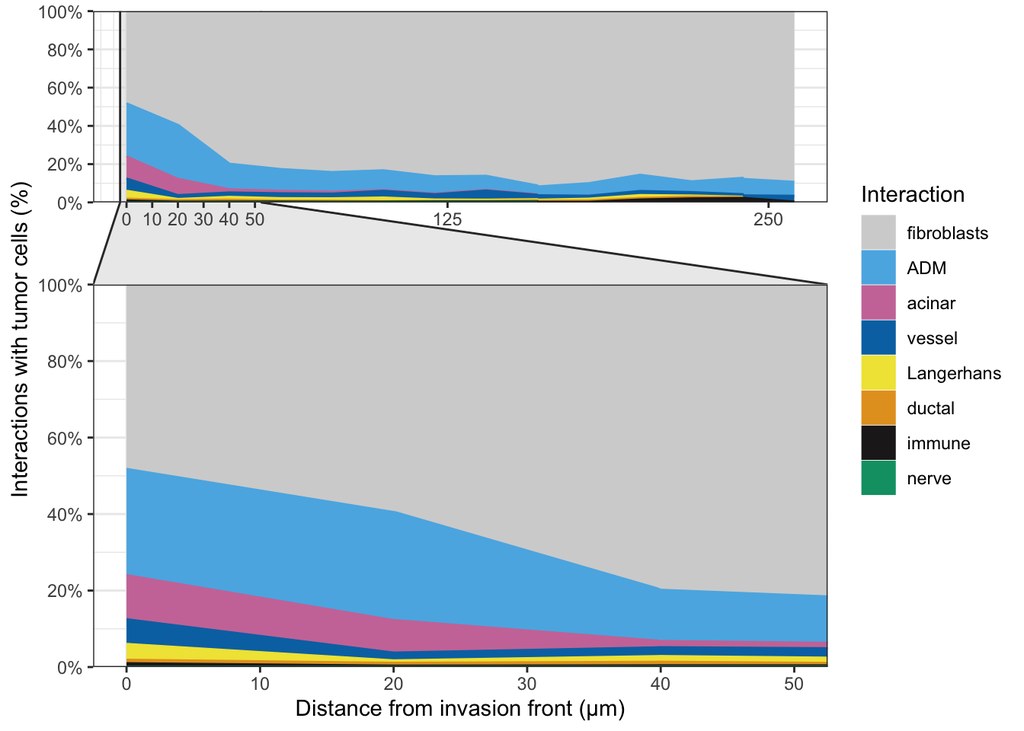

```r
# count percentage of each interaction at different distance point
InvFront.plot <-  invfront.data%>%
  dplyr::select(PKR_ROI,Interaction, Distance_rounded)%>%
  group_by(PKR_ROI,Interaction, Distance_rounded)%>%
  dplyr::summarise(N = n())
data <- InvFront.plot  %>%
    group_by(Distance_rounded, Interaction) %>%
    dplyr::summarise(n = sum(N))
order <- data%>%
  filter(Distance_rounded==0)%>%
  arrange(desc(n))%>%
  pull(Interaction)%>%
  as.vector()


# Stacking order
#order <- c('fibroblasts', 'ADM', 'vessel','Langerhans','acinar', 'ductal', 'immune', 'nerve')
colors <- c('fibroblasts' = "#D3D3D3",'ADM'="#5AB4E5", 'acinar'="#CC79A7",'Langerhans'="#F0E442", 'vessel'="#0073B2", 'ductal'="#E5A024", 'immune'="#231F20", 'nerve'="#009E73")

area.p <- data %>%
  arrange(n) %>%
  mutate(Interaction = factor(Interaction, levels=order)) %>%
  ggplot(aes(Distance_rounded, n, fill = Interaction, label = Interaction, color = Interaction)) +
  geom_area(position = "fill" ) +
  scale_fill_manual(values = colors)+
  scale_color_manual(values = colors)+
  scale_x_continuous(breaks=c(0, 10, 20, 30, 40, 50, 125,250),labels = c("0", "10", "20", "30", "40", "50", "125","250"), limits = c(0,260)) +
  scale_y_continuous(expand = c(0,0), labels = scales::percent, breaks = c(0, 0.2, 0.4, 0.6, 0.8, 1)) +
    facet_zoom(xlim = c(0, 50))+
  labs(x = 'Distance from invasion front (µm)', y = 'Interactions with tumor cells (%)')+
  theme_bw()

area.p
```

```r
# count percentage of each interaction at different distance point
data <-  invfront.data%>%
  dplyr::select(PKR_ROI,Interaction, Distance_rounded)%>%
  group_by(PKR_ROI,Interaction, Distance_rounded)%>%
  dplyr::summarise(N = n())
```

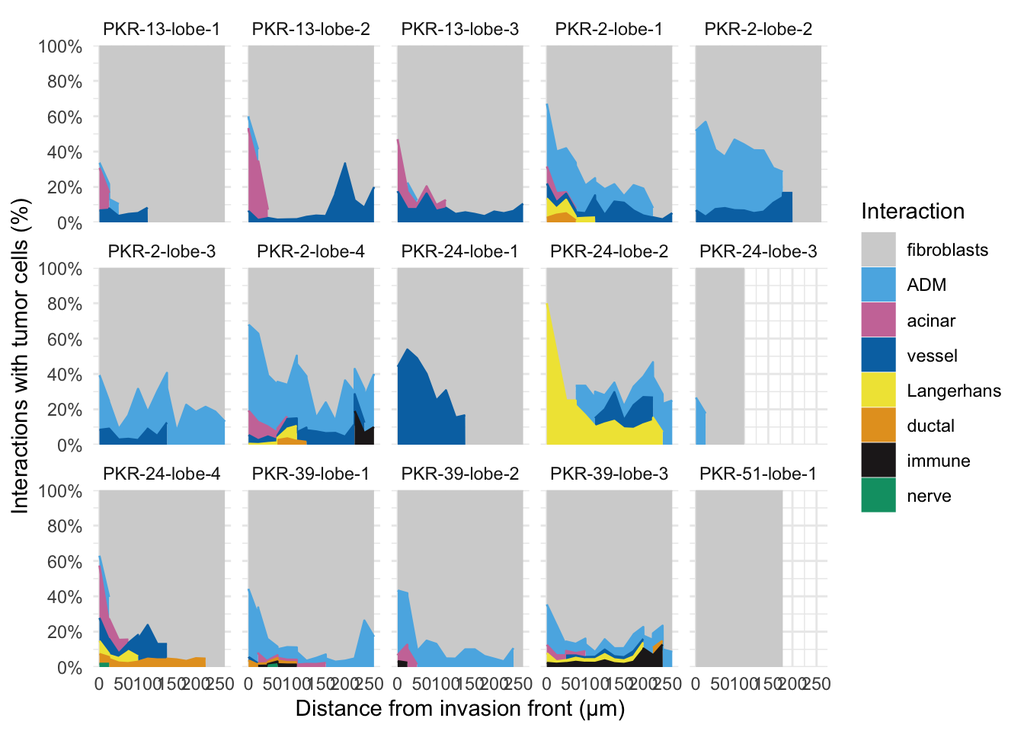

```r
area.p <- data %>%
  arrange(N) %>%
  mutate(Interaction = factor(Interaction, levels=order)) %>%
  ggplot(aes(Distance_rounded, N, fill = Interaction, label = Interaction, color = Interaction)) +
  geom_area(position = "fill" ) +
  scale_fill_manual(values = colors)+
  scale_color_manual(values = colors)+
  scale_x_continuous(breaks=c(0, 50, 100, 150, 200,250),labels = c("0", "50", "100", "150", "200", "250"), limits = c(0,260)) +
  scale_y_continuous(expand = c(0,0), labels = scales::percent, breaks = c(0, 0.2, 0.4, 0.6, 0.8, 1)) +
#    facet_zoom(xlim = c(0, 50))+
  labs(x = 'Distance from invasion front (µm)', y = 'Interactions with tumor cells (%)')+
  theme_minimal()+
  facet_wrap(~PKR_ROI, ncol = 5)

area.p
```

```r
# count percentage of each interaction at different distance point
data <-  invfront.data%>%
  dplyr::select(PKR,Interaction, Distance_rounded)%>%
  group_by(PKR,Interaction, Distance_rounded)%>%
  dplyr::summarise(N = n())
```

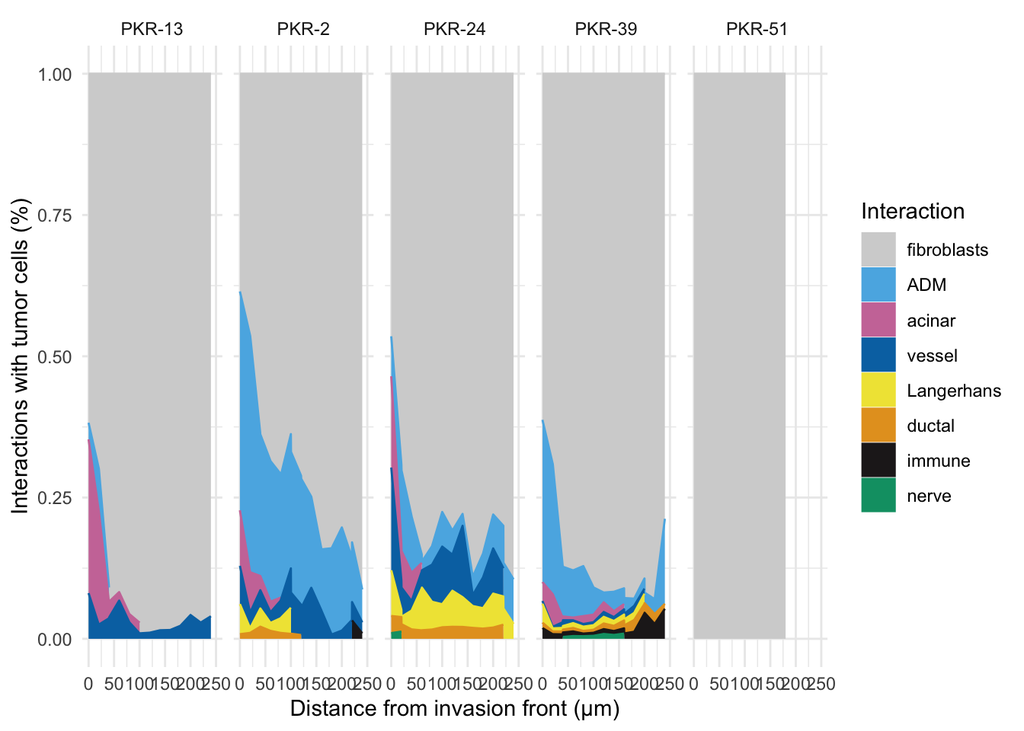

```r
area.p <- data %>%
  arrange(N) %>%
  mutate(Interaction = factor(Interaction, levels=order)) %>%
  ggplot(aes(Distance_rounded, N, fill = Interaction, label = Interaction, color = Interaction)) +
  geom_area(position = "fill" ) +
  scale_fill_manual(values = colors)+
  scale_color_manual(values = colors)+
  xlim(0,250)+
#  scale_x_continuous(breaks=c(0, 10, 20, 30, 40, 50, 125,250,375, 500),labels = c("0", "10", "20", "30", "40", "50", #"125","250","375", "500"), limits = c(0,520)) +
#  scale_y_continuous(expand = c(0,0), labels = scales::percent, breaks = c(0, 0.2, 0.4, 0.6, 0.8, 1)) +
#    facet_zoom(xlim = c(0, 50))+
  labs(x = 'Distance from invasion front (µm)', y = 'Interactions with tumor cells (%)')+
  theme_minimal()+
  facet_wrap(~PKR, ncol = 5)

area.p
```

### 2.4.3 Tumor adjacent tissues within areas of lobular and stromal invasion

```r
# Include also stromal ROIs this time
# use distance less than 20 microns as a criteria for direct interaction and filter away the distances to tumor and invasion front annotations.
dist_frame.direct <- dist_frame %>%
  filter(distance_um < 20 & !to_class %in% c('tumor', 'lobe.1_InvasionFront', 'lobe.2_InvasionFront', 'lobe.3_InvasionFront', 'lobe.4_InvasionFront'))%>%
  data.frame()

# quality control
# information of the data look same than in the beginning but now also stromal interactions are included
cat(paste('The total number of direct interactions with tumor cells is', nrow(dist_frame.direct)), '\n')

cat('of which ')
dist_frame.direct %>%
  filter(roi == 'stroma')%>%
  nrow()
cat(' are in stroma')

cat(' and ')
dist_frame.direct %>%
  filter(roi == 'lobe')%>%
  nrow()
cat(' are in lobes.', '\n')

cat(paste('The total number of ROIs analysed is',length(unique(dist_frame.direct$PKR_ROI))), '\n')

cat('Of which ')
dist_frame.direct %>%
  filter(roi == 'stroma')%>%
  dplyr::select(PKR_ROI)%>%
  unique()%>%
  nrow()

cat(' are stromal ROIs')

cat(' and ')
dist_frame.direct %>%
  filter(roi == 'lobe')%>%
  dplyr::select(PKR_ROI)%>%
  unique()%>%
  nrow()

cat(' lobular ROIs.')

# number of observations for each ROI per case
knitr::kable(dist_frame.direct %>%
  filter(roi == 'lobe')%>%
  dplyr::select(PKR_ROI)%>%
  group_by(PKR_ROI)%>%
  dplyr::summarise(Freq = n()))

knitr::kable(dist_frame.direct %>%
  filter(roi == 'stroma')%>%
  dplyr::select(PKR_ROI)%>%
  group_by(PKR_ROI)%>%
  dplyr::summarise(Freq = n()))

# no missing values
any(is.na(dist_frame.direct))
dist_frame.direct %>%
  filter(is.na(distance_um))
```

```
## The total number of direct interactions with tumor cells is 17938
## of which [1] 8132
##  are in stroma and [1] 9806
##  are in lobes.
## The total number of ROIs analysed is 41
## Of which [1] 26
##  are stromal ROIs and [1] 15
##  lobular ROIs.
```

| PKR_ROI | Freq |
| --- | --- |
| PKR-13-lobe-1 | 325 |
| PKR-13-lobe-2 | 462 |
| PKR-13-lobe-3 | 798 |
| PKR-2-lobe-1 | 1552 |
| PKR-2-lobe-2 | 236 |
| PKR-2-lobe-3 | 975 |
| PKR-2-lobe-4 | 1038 |
| PKR-24-lobe-1 | 128 |
| PKR-24-lobe-2 | 233 |
| PKR-24-lobe-3 | 44 |
| PKR-24-lobe-4 | 660 |
| PKR-39-lobe-1 | 1132 |
| PKR-39-lobe-2 | 1097 |
| PKR-39-lobe-3 | 1000 |
| PKR-51-lobe-1 | 126 |

| PKR_ROI | Freq |
| --- | --- |
| PKR-13-stroma-1 | 341 |
| PKR-13-stroma-2 | 150 |
| PKR-13-stroma-3 | 436 |
| PKR-13-stroma-4 | 372 |
| PKR-13-stroma-5 | 240 |
| PKR-2-stroma-1 | 266 |
| PKR-2-stroma-2 | 310 |
| PKR-2-stroma-3 | 374 |
| PKR-2-stroma-4 | 273 |
| PKR-2-stroma-5 | 167 |
| PKR-2-stroma-6 | 482 |
| PKR-24-stroma-1 | 134 |
| PKR-24-stroma-2 | 217 |
| PKR-24-stroma-3 | 264 |
| PKR-24-stroma-4 | 236 |
| PKR-39-stroma-1 | 573 |
| PKR-39-stroma-2 | 485 |
| PKR-39-stroma-3 | 100 |
| PKR-39-stroma-4 | 591 |
| PKR-39-stroma-5 | 225 |
| PKR-39-stroma-6 | 335 |
| PKR-51-stroma-1 | 247 |
| PKR-51-stroma-2 | 361 |
| PKR-51-stroma-3 | 295 |
| PKR-51-stroma-4 | 105 |
| PKR-51-stroma-5 | 553 |

```
## [1] FALSE
## [1] PKR         roi         roi_no      Object.ID   AP_mean     to_class
## [7] distance_um PKR_ROI
## <0 rows> (or 0-length row.names)
```

#### 2.4.3.1 Comparision of tumor adjacency to tissues based to ML derived annotations to manual classification of tumor adjacent tissues

```r
# import the data
pins <- read.table("./data/manual_pins.tsv", header = TRUE, sep = "\t", dec = ".")

knitr::kable(head(pins))

# each row includes only one contact
pins%>%
  filter(Num.points != 1)

# rename the Class column
pins$Class <- sub("_direct_contact", "", pins$Class)

# chech the Class and Parent names
unique(pins$Class)
unique(pins$Parent)
```

| Image | Object.ID | Name | Class | Parent | ROI | Centroid.X.µm | Centroid.Y.µm | Num.points | Area.µm.2 | Perimeter.µm |
| --- | --- | --- | --- | --- | --- | --- | --- | --- | --- | --- |
| PKR-51-CD146_NGFR_manual_pins_new_rois.ndpi | 9e1500f7-1227-475b-bbc0-74607e9099c1 | Tumor | Tumor | Image | Polygon | 37128.0 | 11862.7 | NA | 92851.6 | 1516.10 |
| PKR-51-CD146_NGFR_manual_pins_new_rois.ndpi | 6066d78b-69e6-4588-b89a-0a54f7a8e2af | Tumor | Tumor | Image | Polygon | 36984.3 | 11986.7 | NA | 1314.2 | 268.30 |
| PKR-51-CD146_NGFR_manual_pins_new_rois.ndpi | 4facbddf-7b32-4272-b960-b2944db5f941 | Tumor | Tumor | Image | Polygon | 35234.5 | 7304.7 | NA | 179403.1 | 2698.50 |
| PKR-51-CD146_NGFR_manual_pins_new_rois.ndpi | 4fbe3b52-4165-4c12-8c2a-f9d18ea11a2a | Tumor | Tumor | Image | Polygon | 35471.0 | 7151.7 | NA | 1747.8 | 180.35 |
| PKR-51-CD146_NGFR_manual_pins_new_rois.ndpi | 128fb6ad-5a80-4f72-a5cd-963561345660 | Tumor | Tumor | Image | Polygon | 30306.3 | 3756.2 | NA | 2056.6 | 219.91 |
| PKR-51-CD146_NGFR_manual_pins_new_rois.ndpi | 50e6cf96-05a8-45df-b176-5277b449ae83 | Tumor | Tumor | Image | Geometry | 30157.6 | 3640.2 | NA | 63174.8 | 1473.00 |

```
##  [1] Image         Object.ID     Name          Class         Parent
##  [6] ROI           Centroid.X.µm Centroid.Y.µm Num.points    Area.µm.2
## [11] Perimeter.µm
## <0 rows> (or 0-length row.names)
##  [1] "Tumor"         "stroma 5"      "fibroblasts"   "??"
##  [5] "small vessels" "Immune cells"  "stroma 2"      "lobe 1"
##  [9] "ADM"           "acinar"        "lobe 3"        "lobe 2"
## [13] "stroma 4"      "stroma 3"      "stroma 1"      "Nerve"
## [1] "Image"    "stroma 5" "stroma 2" "lobe 1"   "lobe 3"   "lobe 2"   "stroma 4"
## [8] "stroma 3" "stroma 1"
```

```r
#subset Aiforia data

pkr51 <- pkr51 %>%
  filter(distance_um < 20 & !to_class %in% c('tumor', 'lobe.1_InvasionFront', 'lobe.2_InvasionFront', 'lobe.3_InvasionFront', 'lobe.4_InvasionFront'))%>%
  data.frame()

pkr51 <- pkr51%>%
  dplyr::select(roi_no, to_class)%>%
  add_count(roi_no, name = 'total')%>%
  group_by(roi_no, to_class, total)%>%
  dplyr::summarise(n = n())%>%
  mutate(percent=n/total*100)
```

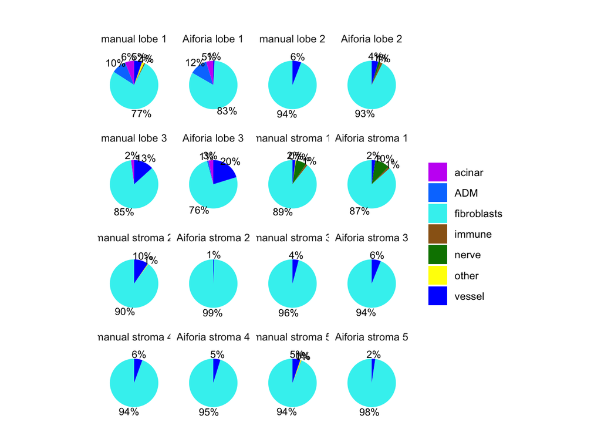

```r
pkr51$roi_no <-paste('Aiforia', pkr51$roi_no)
pkr51$roi_no <-gsub('-', ' ', pkr51$roi_no)

# manual pins data
pkr51.pins <- pins%>%
  filter(Parent != 'Image' & Class != 'Tumor')%>%
  dplyr::select(Parent, Class, Num.points)%>%
  add_count(Parent, name = 'total')%>%
  group_by(Parent, Class, total)%>%
  dplyr::summarise(n = n())%>%
  mutate(percent = n/total*100)%>%
  data.frame()
# harmonize data frame names

colnames(pkr51.pins) <- colnames(pkr51)
pkr51.pins$roi_no <-paste('manual', pkr51.pins$roi_no)
pkr51.pins$to_class <- gsub('[?][?]', 'other', pkr51.pins$to_class)
pkr51.pins$to_class <- gsub('small | cells', '', pkr51.pins$to_class)
pkr51.pins$to_class <- gsub('vessels', 'vessel', pkr51.pins$to_class)
pkr51.pins$to_class <- gsub('N', 'n', pkr51.pins$to_class)
pkr51.pins$to_class <- gsub('I', 'i', pkr51.pins$to_class)

# merge data and arrange by rois
pin.contacts <- rbind(pkr51, pkr51.pins)
pin.contacts$roi_no <- factor(pin.contacts$roi_no, levels = c(
  'manual lobe 1', 'Aiforia lobe 1',
  'manual lobe 2', 'Aiforia lobe 2',
  'manual lobe 3', 'Aiforia lobe 3',
  'manual stroma 1', 'Aiforia stroma 1',
  'manual stroma 2', 'Aiforia stroma 2',
  'manual stroma 3', 'Aiforia stroma 3',
  'manual stroma 4', 'Aiforia stroma 4',
  'manual stroma 5', 'Aiforia stroma 5'
  ))

colors = c("#c714f4","#007cff","#38f0f0","#9a6319", "#008100", "#FFFF00", "#0000ff")

# pie plots
blank_theme <- theme_minimal()+
  theme(
  axis.title.x = element_blank(),
  axis.title.y = element_blank(),
  panel.border = element_blank(),
  panel.grid=element_blank(),
  axis.ticks = element_blank(),
  plot.title=element_text(size=14, face="bold")
  )

pin.pies <- ggplot(pin.contacts, aes(x="", y=percent, fill=to_class))+
  geom_bar(width = 1, stat = 'identity')+
  scale_fill_manual(values=colors)+
  coord_polar("y", start=0)+
  geom_text(aes(x = 1.7, label = paste0(round(percent), "%")), size=3,
            position = position_stack(vjust = 0.5))+
  labs(x = NULL, y = NULL, fill = NULL, title = "")+
  theme_minimal()+
  blank_theme+
  theme(
  axis.text.x = element_blank())+
  facet_wrap(~roi_no)

pin.pies
```

#### 2.4.3.2 Visualistion of ML derived annotation based interactions in stroma and lobules

```r
# data for Sankey plot of interactions
Sankey.data <- dist_frame.direct%>%
  dplyr::select(roi, to_class)%>%
  group_by(roi, to_class, .drop=FALSE)%>%
  plyr::count()%>%
  mutate(total = sum(freq),
         percent=freq/total*100)%>%
  data.frame()

knitr::kable(Sankey.data)
```

| roi | to_class | freq | total | percent |
| --- | --- | --- | --- | --- |
| lobe | acinar | 251 | 17938 | 1.3992641 |
| lobe | ADM | 1182 | 17938 | 6.5893634 |
| lobe | ductal | 34 | 17938 | 0.1895418 |
| lobe | fibroblasts | 7896 | 17938 | 44.0182852 |
| lobe | immune | 42 | 17938 | 0.2341398 |
| lobe | Langerhans | 115 | 17938 | 0.6410971 |
| lobe | nerve | 5 | 17938 | 0.0278738 |
| lobe | vessel | 281 | 17938 | 1.5665069 |
| stroma | fibroblasts | 7888 | 17938 | 43.9736871 |
| stroma | immune | 19 | 17938 | 0.1059204 |
| stroma | nerve | 107 | 17938 | 0.5964991 |
| stroma | vessel | 118 | 17938 | 0.6578214 |

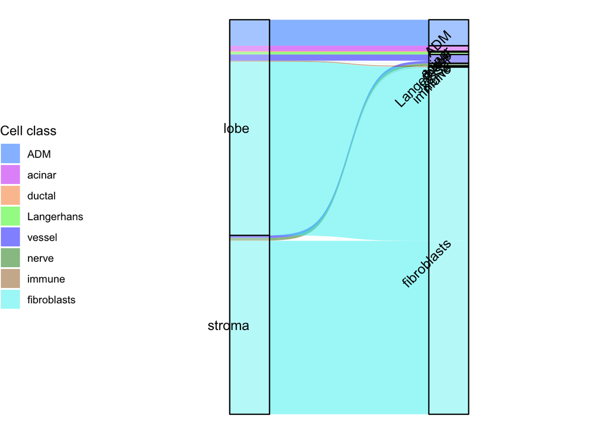

```r
colors = c("#007cff", "#c714f4", "#f78120", "#1bf200", "#0000ff", "#008100","#9a6319","#38f0f0")

Sankey.data$to_class <- factor(Sankey.data$to_class, levels = c('ADM', 'acinar', 'ductal', 'Langerhans', 'vessel', 'nerve', 'immune',  'fibroblasts'))

ggplot(data = Sankey.data,
       aes(axis1 = roi, axis2 = to_class, y = percent)) +
  geom_alluvium(aes(fill = to_class),
                width = 0.2, knot.pos = 0, reverse = T,
                curve_type = "sigmoid") +
  geom_stratum(alpha = 0.25, width = 0.2, reverse = T) +
  geom_text(stat = "stratum",
            aes(label = after_stat(stratum)), reverse = T,
            angle=c(0,0,rep(45,8)),size=4, hjust = 1, vjust = 0.5) +
  scale_x_discrete(limits = c("roi", "to_class"),
                   expand = c(0.5, 0.3)) +
  scale_fill_manual(values = colors)+
  theme_void()+
  theme(legend.position = "left")+
  guides(fill = guide_legend(title = "Cell class"))
```

#### 2.4.3.3 Visualisation of ML derived annotation based interactions in stroma and lobules without fibrosis

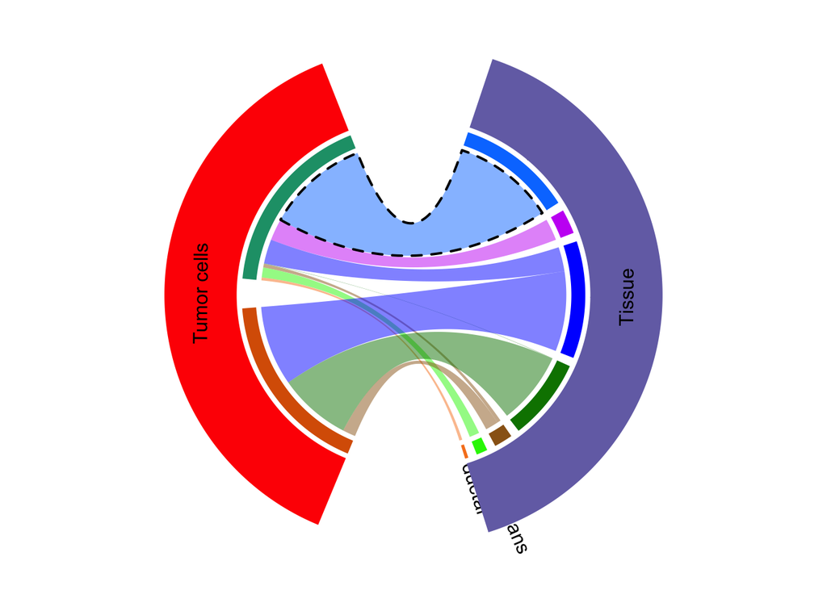

```r
# normalize non-fibrosis interactions within the interactions in lobes or in stroma
circ.data <- Sankey.data%>%
  dplyr::filter(to_class != 'fibroblasts')%>%
  dplyr::select(roi, to_class, freq)%>%
  group_by(roi)%>%
  dplyr::mutate(total = sum(freq),
         ratio = freq/total)%>%
  data.frame()

cell_rate <- tapply(circ.data$ratio, circ.data$to_class, FUN = sum)
cell_rate <- data.frame(cell_rate)

# fibroblasts class pop ups again!
# getting rows
rows <- c(rownames(cell_rate))

# extracting data frame rows
cell_rate <- cell_rate[rownames(cell_rate) %in% rows[-8], ]
cell_rate <- data.frame(cell_rate) # other rownames and data frame structure is lost
rownames(cell_rate) <- rows[-8]

cell_rate <- cell_rate[order(cell_rate$cell_rate, decreasing = TRUE),,drop=FALSE]

circos_rel <- circ.data%>%
  dplyr::select(roi, to_class, ratio)%>%
  data.frame()

order = c("stroma", "lobe", "ADM", "acinar", 'vessel', "nerve", "immune","Langerhans","ductal")

col = c("#c714f4","#007cff","#f78120", "#9a6319","#1bf200", "#008100", "#0000ff", "#9a6319", "#008100", "#0000ff")
grid.col = c(lobe = '#1b9e77', stroma = '#d95f02',
             ADM = "#007cff", Langerhans = "#1bf200", acinar = "#c714f4", ductal = "#f78120", immune = "#9a6319", nerve = "#008100", vessel = "#0000ff")

circos.clear()
circos.par(gap.after = c(10, 40, rep(3, length(row.names(cell_rate))-1), 40),
           start.degree = -112.5)
chordDiagram(circos_rel,
             order = order,
             col = col,
             grid.col = grid.col,
             link.lty =c(0,2,0,0,0,0,0,0,0,0),
    link.lwd = c(2,2,rep(1,(nrow(circos_rel)-2)*2)), link.border = c(0,1,0,0,0,0,0,0,0,0),
             annotationTrack = "grid",
             preAllocateTracks = list(track.height = max(strwidth(unlist(dimnames(circos_rel))))))

# customize sector labels
circos.track(track.index = 1, panel.fun = function(x, y) {
    circos.text(CELL_META$xcenter, CELL_META$ylim[1], CELL_META$sector.index,
        facing = "clockwise", niceFacing = TRUE, adj = c(0, 0.5))
}, bg.border = NA) # here set bg.border to NA is important

highlight.sector(c('lobe', 'stroma'), track.index = 1, col = "#FF0000",
    text = "Tumor cells", cex = 1, text.col = "black", niceFacing = TRUE)

highlight.sector(c("ADM", "acinar", 'vessel', "nerve", "immune","Langerhans","ductal"), track.index = 1, col = '#7570b3',
    text = "Tissue", cex = 1, text.col = "black", niceFacing = TRUE)
```

```r
#abline(h = 0, lty = 2, col = "lightpink")
```

# 3 NGFR intensity of expanded area from acinar, acinar-to-ductal-metaplasia (ADM) and tumor cell detections in areas of lobular invasion

## 3.1 Import the acinar and ADM based intensity measurements

```r
# acinar cell detection based intensity measurements based on the surrounding tissue
acinar.original <- read.table('./data/ngfr_intensity_acinar.tsv', sep = '\t', header = T)
dim(acinar.original) #23975 observations in total

# ADM cell detection based intensity measurements based on the surrounding tissue
ADM.original <- read.table('./data/ngfr_intensity_ADM.tsv', sep = '\t', header = T)
dim(ADM.original) #20857 observations in total

knitr::kable(head(acinar.original))
knitr::kable(head(ADM.original))
```

```
## [1] 23975    97
## [1] 20857    97
```

| Image | Object.ID | Name | Class | Parent | ROI | Centroid.X.µm | Centroid.Y.µm | Nucleus..Area | Nucleus..Perimeter | Nucleus..Circularity | Nucleus..Max.caliper | Nucleus..Min.caliper | Nucleus..Eccentricity | Nucleus..Hematoxylin.OD.mean | Nucleus..Hematoxylin.OD.sum | Nucleus..Hematoxylin.OD.std.dev | Nucleus..Hematoxylin.OD.max | Nucleus..Hematoxylin.OD.min | Nucleus..Hematoxylin.OD.range | Nucleus..DAB.OD.mean | Nucleus..DAB.OD.sum | Nucleus..DAB.OD.std.dev | Nucleus..DAB.OD.max | Nucleus..DAB.OD.min | Nucleus..DAB.OD.range | Nucleus..AP.OD.mean | Nucleus..AP.OD.sum | Nucleus..AP.OD.std.dev | Nucleus..AP.OD.max | … |
| --- | --- | --- | --- | --- | --- | --- | --- | --- | --- | --- | --- | --- | --- | --- | --- | --- | --- | --- | --- | --- | --- | --- | --- | --- | --- | --- | --- | --- | --- | --- |
| PKR-2-cd146_ngfr distance_to_preserved_lobules_wIntensityAcinartest.ndpi (1) | a779ec1f-2ff9-4220-b09c-35c375e468b8 | lobe 1 | lobe 1 | lobe 1 | Polygon | 31848.2 | 11200.6 | 30.1334 | 27.9332 | 0.4853 | 10.6113 | 5.2796 | 0.8755 | -0.0353 | -5.2255 | 0.1346 | 0.3324 | -0.3725 | 0.7049 | -0.0475 | -7.0311 | 0.1117 | 0.1697 | -0.3315 | 0.5012 | 0.7055 | 104.4197 | 0.3047 | 1.5567 | … |
| PKR-2-cd146_ngfr distance_to_preserved_lobules_wIntensityAcinartest.ndpi (1) | 491deeb9-b949-46ae-8cf1-f1cfa800845c | lobe 1 | lobe 1 | lobe 1 | Polygon | 31863.0 | 11214.2 | 39.6828 | 23.1751 | 0.9285 | 8.0601 | 6.5011 | 0.5850 | 0.3164 | 61.0663 | 0.1041 | 0.6133 | 0.0267 | 0.5866 | 0.2468 | 47.6341 | 0.0874 | 0.4866 | 0.0083 | 0.4783 | 0.1323 | 25.5406 | 0.0867 | 0.3369 | … |
| PKR-2-cd146_ngfr distance_to_preserved_lobules_wIntensityAcinartest.ndpi (1) | 9d1d599d-22b6-4f0c-9cf7-0f48fc17cf1a | lobe 1 | lobe 1 | lobe 1 | Polygon | 30190.0 | 11595.5 | 26.7381 | 19.6423 | 0.8709 | 7.0525 | 5.4029 | 0.5570 | 0.2066 | 27.2690 | 0.0813 | 0.4432 | 0.0493 | 0.3939 | 0.1719 | 22.6872 | 0.1374 | 0.8902 | -0.0107 | 0.9009 | -0.0367 | -4.8424 | 0.0577 | 0.0949 | … |
| PKR-2-cd146_ngfr distance_to_preserved_lobules_wIntensityAcinartest.ndpi (1) | b72829e3-312f-43b7-90de-050f3f5f63a0 | lobe 1 | lobe 1 | lobe 1 | Polygon | 30167.1 | 11604.0 | 44.1391 | 24.4655 | 0.9267 | 9.1661 | 6.4489 | 0.6944 | 0.5028 | 105.5861 | 0.1405 | 0.9806 | 0.1782 | 0.8024 | 0.2182 | 45.8138 | 0.1107 | 0.5310 | -0.0403 | 0.5713 | -0.0597 | -12.5342 | 0.1215 | 0.2288 | … |
| PKR-2-cd146_ngfr distance_to_preserved_lobules_wIntensityAcinartest.ndpi (1) | 94ddba74-f89c-49bf-982d-154e19833d48 | lobe 1 | lobe 1 | lobe 1 | Polygon | 30188.6 | 11608.6 | 26.7381 | 18.9728 | 0.9334 | 7.1047 | 4.9336 | 0.7204 | 0.5773 | 74.4653 | 0.1719 | 0.9680 | 0.0816 | 0.8863 | 0.3324 | 42.8776 | 0.0786 | 0.6286 | 0.1161 | 0.5125 | -0.0446 | -5.7528 | 0.1076 | 0.2834 | … |
| PKR-2-cd146_ngfr distance_to_preserved_lobules_wIntensityAcinartest.ndpi (1) | 3d17e42e-f97b-4e59-a15f-baa0c9c2e373 | lobe 1 | lobe 1 | lobe 1 | Polygon | 30174.9 | 11614.1 | 29.9212 | 22.5993 | 0.7362 | 8.4568 | 5.5208 | 0.7561 | 0.4887 | 71.8377 | 0.1679 | 0.9652 | 0.0451 | 0.9201 | 0.1648 | 24.2235 | 0.1153 | 0.4432 | -0.0641 | 0.5073 | -0.0852 | -12.5222 | 0.0935 | 0.1984 | … |

| Image | Object.ID | Name | Class | Parent | ROI | Centroid.X.µm | Centroid.Y.µm | Nucleus..Area | Nucleus..Perimeter | Nucleus..Circularity | Nucleus..Max.caliper | Nucleus..Min.caliper | Nucleus..Eccentricity | Nucleus..Hematoxylin.OD.mean | Nucleus..Hematoxylin.OD.sum | Nucleus..Hematoxylin.OD.std.dev | Nucleus..Hematoxylin.OD.max | Nucleus..Hematoxylin.OD.min | Nucleus..Hematoxylin.OD.range | Nucleus..DAB.OD.mean | Nucleus..DAB.OD.sum | Nucleus..DAB.OD.std.dev | Nucleus..DAB.OD.max | Nucleus..DAB.OD.min | Nucleus..DAB.OD.range | Nucleus..AP.OD.mean | Nucleus..AP.OD.sum | Nucleus..AP.OD.std.dev | Nucleus..AP.OD.max | … |
| --- | --- | --- | --- | --- | --- | --- | --- | --- | --- | --- | --- | --- | --- | --- | --- | --- | --- | --- | --- | --- | --- | --- | --- | --- | --- | --- | --- | --- | --- | --- |
| PKR-2-cd146_ngfr distance_to_preserved_lobules_wIntensityADMtest.ndpi | b6ec63a6-bc87-4e0d-9d31-6d2453ecb322 | lobe 1 | lobe 1 | lobe 1 | Polygon | 32036.2 | 10869.6 | 35.2264 | 23.5286 | 0.7996 | 8.1479 | 6.4155 | 0.6285 | 0.5500 | 90.7571 | 0.3011 | 1.9127 | -0.1354 | 2.0481 | 0.3412 | 56.2917 | 0.5382 | 3.9444 | -0.3009 | 4.2453 | 0.1579 | 26.0493 | 0.4381 | 1.2380 | … |
| PKR-2-cd146_ngfr distance_to_preserved_lobules_wIntensityADMtest.ndpi | e1fd3d30-7a37-4307-83e0-209e164f106e | lobe 1 | lobe 1 | lobe 1 | Polygon | 32022.3 | 10873.2 | 35.4386 | 27.6319 | 0.5833 | 10.9333 | 5.7809 | 0.8224 | 0.6798 | 117.6042 | 0.5101 | 2.3828 | -0.6462 | 3.0290 | 0.9821 | 169.8981 | 0.5168 | 4.1118 | 0.1001 | 4.0117 | -0.0349 | -6.0299 | 0.4799 | 1.9237 | … |
| PKR-2-cd146_ngfr distance_to_preserved_lobules_wIntensityADMtest.ndpi | c84e8ff5-4646-4283-a068-45bcb9042e24 | lobe 1 | lobe 1 | lobe 1 | Polygon | 32050.5 | 10877.9 | 54.1129 | 38.5111 | 0.4585 | 13.1553 | 8.1821 | 0.6779 | 0.3236 | 81.8623 | 0.3046 | 1.5203 | -0.4337 | 1.9540 | 0.5463 | 138.2092 | 0.3478 | 1.4687 | -1.3585 | 2.8272 | 0.1396 | 35.3094 | 0.4390 | 2.7293 | … |
| PKR-2-cd146_ngfr distance_to_preserved_lobules_wIntensityADMtest.ndpi | eb13c2c5-3a8c-4096-8955-7a1ee8520ca9 | lobe 1 | lobe 1 | lobe 1 | Polygon | 32030.7 | 10881.9 | 46.4734 | 30.3737 | 0.6330 | 11.5502 | 6.6124 | 0.8343 | 0.7728 | 171.5529 | 0.4518 | 3.2741 | -0.1290 | 3.4031 | 0.8141 | 180.7345 | 0.5427 | 3.6904 | -0.1442 | 3.8346 | -0.0619 | -13.7321 | 0.5392 | 2.3719 | … |
| PKR-2-cd146_ngfr distance_to_preserved_lobules_wIntensityADMtest.ndpi | d9c7503b-f99c-4c68-ab8b-5dca8a797103 | lobe 1 | lobe 1 | lobe 1 | Polygon | 32040.6 | 10883.8 | 31.1945 | 23.1747 | 0.7299 | 8.0009 | 6.3891 | 0.4462 | 0.4941 | 75.0992 | 0.3602 | 2.0341 | -0.1548 | 2.1889 | 0.9400 | 142.8782 | 0.3680 | 2.1267 | 0.1482 | 1.9786 | -0.0106 | -1.6066 | 0.3336 | 0.6302 | … |
| PKR-2-cd146_ngfr distance_to_preserved_lobules_wIntensityADMtest.ndpi | c4b1958a-6aeb-4bc7-8d13-adecd45ebc7b | lobe 1 | lobe 1 | lobe 1 | Polygon | 32024.0 | 10890.0 | 53.6885 | 31.7738 | 0.6683 | 11.9475 | 7.0371 | 0.7689 | 0.5961 | 152.6104 | 0.3910 | 2.3089 | -0.4554 | 2.7643 | 0.9632 | 246.5698 | 0.4005 | 3.4633 | -0.3070 | 3.7703 | 0.0437 | 11.1933 | 0.3652 | 1.1106 | … |

## 3.2 Clean-up

```r
acinar <- acinar.original%>%
  mutate(cell_type = c(rep('Acinar', nrow(acinar.original))))

ADM <- ADM.original%>%
  mutate(cell_type = c(rep('ADM', nrow(ADM.original))))


ngfr.data <- rbind(acinar, ADM)

# select only relevant columns
ngfr.data <- ngfr.data %>%
  dplyr::select(Image, Class, cell_type, ends_with(c('AP..Mean', 'fibroblasts.µm')))%>%
  data.frame()

ngfr.data$Image <- gsub("-CD146.*|-cd146.*","",ngfr.data$Image)
unique(ngfr.data$Image) # only case information left
```

[1] “PKR-2” “PKR-13” “PKR-24” “PKR-51”

```r
colnames(ngfr.data) <- c('PKR', 'ROI', 'cell_type', 'AP_mean', 'distance_to_fibroblasts')

#create a new column to have plain info on the ROI (stroma/lobe)
ngfr.data <- ngfr.data %>%
  tidyr::separate(col=ROI, into=c('roi', 'roi_no'), sep = ' ', remove = T)%>%
  mutate(roi_no = paste(roi, roi_no, sep="-"))%>%
  data.frame()

# add a column with combined case and ROI info
ngfr.data$PKR_ROI = paste(ngfr.data$PKR, ngfr.data$roi_no, sep="-")

nrow(ngfr.data)
```

[1] 44832

```r
# exclude PKR-51 lobes 2 and 3
#include only measurements locating next to class "fibroblasts"
ngfr.data <- ngfr.data%>%
  filter(!PKR_ROI %in% c('PKR-51-lobe-2', 'PKR-51-lobe-3') & distance_to_fibroblasts<20)%>%
  data.frame()

nrow(ngfr.data) #28700 rows were excluded
```

[1] 16132

```r
unique(ngfr.data$PKR_ROI)
```

[1] “PKR-2-lobe-1” “PKR-2-lobe-3” “PKR-2-lobe-4” “PKR-2-lobe-2” [5] “PKR-13-lobe-2” “PKR-13-lobe-3” “PKR-13-lobe-1” “PKR-24-lobe-2” [9] “PKR-24-lobe-4” “PKR-24-lobe-1” “PKR-24-lobe-3” “PKR-51-lobe-1”

```r
# number of acinar cells
ngfr.data%>%
  filter(cell_type=='Acinar')%>%
  nrow()
```

[1] 5702

```r
# number of ADM cells
ngfr.data%>%
  filter(cell_type=='ADM')%>%
  nrow()
```

[1] 10430

```r
# convertion & new columns look as they should
knitr::kable(head(ngfr.data))
```

| PKR | roi | roi_no | cell_type | AP_mean | distance_to_fibroblasts | PKR_ROI |
| --- | --- | --- | --- | --- | --- | --- |
| PKR-2 | lobe | lobe-1 | Acinar | 0.2176 | 13.9292 | PKR-2-lobe-1 |
| PKR-2 | lobe | lobe-1 | Acinar | 0.1746 | 10.2890 | PKR-2-lobe-1 |
| PKR-2 | lobe | lobe-1 | Acinar | 0.1728 | 16.4824 | PKR-2-lobe-1 |
| PKR-2 | lobe | lobe-1 | Acinar | 0.2339 | 8.4558 | PKR-2-lobe-1 |
| PKR-2 | lobe | lobe-1 | Acinar | 0.2493 | 6.0138 | PKR-2-lobe-1 |
| PKR-2 | lobe | lobe-1 | Acinar | 0.2980 | 10.1679 | PKR-2-lobe-1 |

## 3.3 Visualization of NGFR intensity of the surrounding tissue of tumor cells in the areas of lobular invasion

```r
#check in which data the maximum per case is recorded (tumor cell based on acinar/ADM cell based)
tumor_intensities <- invfront.data%>%
  filter(PKR != 'PKR-39' & Interaction == 'fibroblasts')%>%
  dplyr::select(Object.ID, PKR, PKR_ROI, distance_to_invf, AP_mean)

# compare max values
tumor_max <- tumor_intensities%>%
  dplyr::select(PKR, AP_mean)%>%
  group_by(PKR)%>%
  summarise(AP_max_tumor = max(AP_mean))

acini_max <- ngfr.data%>%
  dplyr::select(PKR, AP_mean)%>%
  group_by(PKR)%>%
  summarise(AP_max_acini = max(AP_mean))

max_compare <- merge(x = tumor_max, y = acini_max, by = 'PKR')

max_compare <- max_compare%>%
  mutate(tumor_AP_higher = case_when(AP_max_tumor>AP_max_acini~'TRUE',
                                     TRUE~'FALSE'))
knitr::kable(max_compare) # maximum values in acini/adm based measures
```

| PKR | AP_max_tumor | AP_max_acini | tumor_AP_higher |
| --- | --- | --- | --- |
| PKR-13 | 0.4802 | 0.6347 | FALSE |
| PKR-2 | 0.4449 | 0.6441 | FALSE |
| PKR-24 | 0.2283 | 0.4225 | FALSE |
| PKR-51 | 0.0717 | 0.5299 | FALSE |

```r
# normalization to the max intesity in each case
tumor_intensities <- merge(x = tumor_intensities, y = acini_max, by = 'PKR')

# mean lines for plot
lines <- ngfr.data%>%
  mutate(AP_mean = case_when(AP_mean<0~0,
                              TRUE ~AP_mean))%>% #negative intensities to positive
  group_by(PKR)%>% # normalize ngfr intensity
  mutate(AP_max=max(AP_mean),
           AP_norm=(AP_mean/AP_max))%>%
  dplyr::select(cell_type, AP_norm) %>% #compute mean
  group_by(cell_type)%>%
  summarise(Mean_AP_norm=mean(AP_norm))
# create distance bins according to rolling mean
tumor_intensities$distanceR <- plyr::round_any(tumor_intensities$distance_to_invf, 50)

# normalize tumor intensities and subset data for plotting
tumor_intensities <- tumor_intensities %>%
  mutate(AP_mean = case_when(AP_mean<0~0,
                              TRUE ~AP_mean),
         AP_norm = AP_mean/AP_max_acini)%>%
  group_by(distanceR)%>% # rolling mean and standard deviation
  mutate(AP_rollmean = mean(AP_norm, na.rm = T),
         AP_rollsd = sd(AP_norm, na.rm = T))

# number of individual tumor cells
nrow(tumor_intensities)
```

```
## [1] 5103
```

```r
length(unique(tumor_intensities$Object.ID))
```

```
## [1] 5103
```

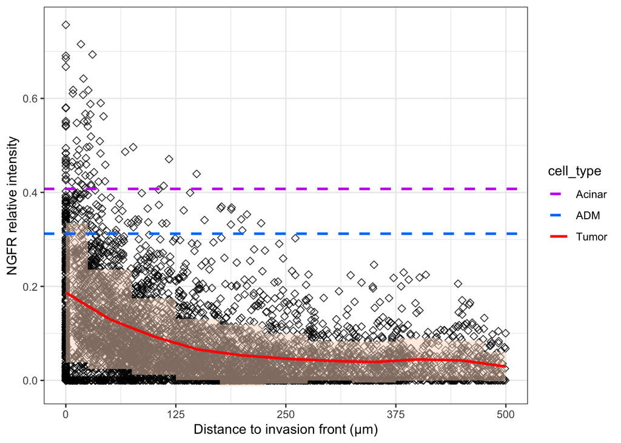

```r
# plots of intensities
ggplot(tumor_intensities, aes(x=distance_to_invf, y=AP_norm)) +
  geom_point(size=2, shape=23, alpha=0.8) +
  scale_color_manual(values = c('#636363'))+
  geom_ribbon(aes(ymin = AP_rollmean - AP_rollsd, ymax = AP_rollmean + AP_rollsd), fill = '#fddbc7', alpha = 0.5)+
  geom_line(aes(y = AP_rollmean,  x = distanceR, linetype = 'Tumor'), color = c('#FF0000'), linewidth = 1)+
  geom_hline(aes(yintercept = lines$Mean_AP_norm[1], linetype = 'ADM'), colour = c("#007cff"), linewidth = 1) +
  geom_hline(aes(yintercept = lines$Mean_AP_norm[2], linetype = 'Acinar'), colour = c("#c714f4"), linewidth = 1) +
  scale_linetype_manual(name = "cell_type", values = c(2, 2, 1),
                      guide = guide_legend(override.aes = list(color = c("#c714f4", "#007cff", "#FF0000"))))+
  scale_x_continuous(breaks=c(0, 125,250,375, 500),labels = c("0", "125","250","375", "500"), limits = c(0,500))+
  labs(y = 'NGFR relative intensity', x ='Distance to invasion front (µm)')+
  theme_bw()
```